# EF tasks markdown 2020

Christoph Voelter

January 26, 2020

### Selection of task DVs

- All DVs have been scaled to values between 0 and 1 with higher values indicating better performance.
- Inhibition tasks: proportion correct in *first session*. First session performance shows signature of prepotent response. Increase of side biases in the second session of the inhibition boxes task. Previous findings with the WKPRC chimpanzees showed performance improvements in the inhibition cylinder task within the first session. Comparability to children who completed only one session.
- Shifting tasks: Shifting Boxes: Proportion correct in the CD phase (as measure of susceptibility to interference from anonther stimulus dimension); Shifting Shelf task: proportion of platform switches; Shifting Trays task: proportion correct in session 2. DVs were selected that show large individual variation and above chance performance (in contrast to the ED phase in the Shifting Boxes task and the first session in the Shifting Tray task).
- Working memory: WM Boxes and WM Updating (both platforms): proportion of correct choices; WM Grid: proximity of first choice to the baited compartment (ranging between 0 and 1). DVs capture the test performance (in the presence of a secondary task).

Missing values: Total number of individuals: 53 (two subjects excluded) Complete cases: 48 completed all 9 tasks Incomplete cases: * George completed 1 task (inhibition grid) –> exclude * Saidia completed 2 tasks (inhibition grid and inhibition cylinder) –> exclude * Edvard completed 7 tasks (all except inhibition grid and inhibition cylinder). Edvard did not eat peanuts and therefore did not engage in the inhibition cylinder task, * Jane completed 8 tasks (all except inhibition cylinder). Jane found a transprent closed cylidners before the first session due to remaining cylinders in one of the enclosures * Julia completed 8 tasks (all except shifting shelf). Julia did not finish training 2 (not motivated) * Mwanzo completed 8 tasks (all except shifting shelf). Mwanzo failed Training 1 within 72 trials. * Safari completed 7 tasks (all except shifting shelf and shifting tray). Safari refused to participate in more than a few trials per day. He completed 11 trials in the shifting tray task within 4 days. Safari did not finish training 1 in the shifting shelf task. (* Tess completed all 9 tasks but did not receive the simple reversal task due to an experimenter mistake) * Mawa completed all tasks but his second inhibition cylinder session cannot be counted.

```r
# Center and scale the factors
EF_task_data[,-(1)] = scale(EF_task_data[,-(1)])


fit_model = function(model) {
    fit = bcfa(model, data = EF_task_data, orthogonal=TRUE, adapt = 2000, burnin = 2000)
    return(fit)
}


model.MF2012 <- 'F1_WM =~  WMUpdating   + WMBoxes + WMGrid
                F2_Shifting =~  CD_all + Shelf + Tray
                F3_CommonEF =~  InhibGrid + Cylinder + GlassCeiling + Shelf + CD_all + Tray + WMUpdating+ WMBoxes + WMGrid'

model.9factors <- 'F1 =~  WMUpdating
              F2 =~  WMBoxes
              F3 =~  WMGrid
              F4 =~  CD_all
              F5 =~  Shelf
              F6 =~  Tray
              F7 =~  InhibGrid
              F8 =~  Cylinder
              F9 =~  GlassCeiling'


model.3factors <- 'F1_WM =~  WMUpdating + WMBoxes + WMGrid
                F2_Shifting =~  CD_all + Shelf + Tray
                  F3_Inhibition =~  InhibGrid + Cylinder + GlassCeiling'

model.1factor <- 'F1_CommonEF =~  InhibGrid + Cylinder + GlassCeiling + Shelf + CD_all + Tray + WMUpdating+ WMBoxes + WMGrid'

model.3factors_ind <- 'F1_WM =~  WMUpdating + WMBoxes + WMGrid
                F2_Shifting =~  CD_all + Shelf + Tray
                  F3_Inhibition =~  InhibGrid + Cylinder + GlassCeiling'

model.2factors1 <- 'F1_2_WM_Shifting =~  WMUpdating + WMBoxes + WMGrid+ CD_all + Shelf + Tray
                   F3_Inhibition =~  InhibGrid + Cylinder + GlassCeiling'

model.2factors2 <- 'F1_3_WM_Inh =~  WMUpdating + WMBoxes + WMGrid + InhibGrid + Cylinder + GlassCeiling
                    F2_Shifting =~  CD_all + Shelf + Tray'

model.2factors3 <- 'F1_WM =~  WMUpdating + WMBoxes + WMGrid
                    F2_3_Shifting_Inh=~ CD_all + Shelf + Tray + InhibGrid + Cylinder + GlassCeiling'

# Fit each of the models
bfit.MF2012 = fit_model(model.MF2012)
bfit.3factors = fit_model(model.3factors)
bfit.1factor = fit_model(model.1factor)
bfit.3factors_ind = fit_model(model.3factors_ind)
bfit.2factors1 = fit_model(model.2factors1)
bfit.2factors2 = fit_model(model.2factors2)
bfit.2factors3 = fit_model(model.2factors3)
bfit.9factors = fit_model(model.9factors)
```

```r
# Compare models to the MF2012 model
blavCompare(bfit.MF2012, bfit.MF2012)
```

```
##
## WAIC estimates:
##  object1:  1357.891
##  object2:  1357.891
##
## WAIC difference & SE:
##     0.000    0.000
##
## LOO estimates:
##  object1:  1358.247
##  object2:  1358.247
##
## LOO difference & SE:
##     0.000    0.000
##
## Laplace approximation to the log-Bayes factor
## (experimental; positive values favor object1):    0.000
```

```r
blavCompare(bfit.MF2012, bfit.3factors)
```

```
##
## WAIC estimates:
##  object1:  1357.891
##  object2:  1359.327
##
## WAIC difference & SE:
##    -0.718    2.012
##
## LOO estimates:
##  object1:  1358.247
##  object2:  1359.595
##
## LOO difference & SE:
##    -0.674    2.042
##
## Laplace approximation to the log-Bayes factor
## (experimental; positive values favor object1):  -14.278
```

```r
blavCompare(bfit.MF2012, bfit.1factor)
```

```
##
## WAIC estimates:
##  object1:  1357.891
##  object2:  1358.996
##
## WAIC difference & SE:
##    -0.553    1.340
##
## LOO estimates:
##  object1:  1358.247
##  object2:  1359.438
##
## LOO difference & SE:
##    -0.595    1.353
##
## Laplace approximation to the log-Bayes factor
## (experimental; positive values favor object1):  -11.184
```

```r
blavCompare(bfit.MF2012, bfit.3factors_ind)
```

```
##
## WAIC estimates:
##  object1:  1357.891
##  object2:  1358.752
##
## WAIC difference & SE:
##    -0.430    1.937
##
## LOO estimates:
##  object1:  1358.247
##  object2:  1358.924
##
## LOO difference & SE:
##    -0.338    1.971
##
## Laplace approximation to the log-Bayes factor
## (experimental; positive values favor object1):  -16.978
```

```r
blavCompare(bfit.MF2012, bfit.2factors1)
```

```
##
## WAIC estimates:
##  object1:  1357.891
##  object2:  1357.545
##
## WAIC difference & SE:
##    -0.173    2.094
##
## LOO estimates:
##  object1:  1358.247
##  object2:  1357.978
##
## LOO difference & SE:
##    -0.135    2.117
##
## Laplace approximation to the log-Bayes factor
## (experimental; positive values favor object1):  -12.036
```

```r
blavCompare(bfit.MF2012, bfit.2factors2)
```

```
##
## WAIC estimates:
##  object1:  1357.891
##  object2:  1359.852
##
## WAIC difference & SE:
##    -0.980    2.118
##
## LOO estimates:
##  object1:  1358.247
##  object2:  1360.211
##
## LOO difference & SE:
##    -0.982    2.153
##
## Laplace approximation to the log-Bayes factor
## (experimental; positive values favor object1):  -12.284
```

```r
blavCompare(bfit.MF2012, bfit.2factors3)
```

```
##
## WAIC estimates:
##  object1:  1357.891
##  object2:  1359.897
##
## WAIC difference & SE:
##    -1.003    1.476
##
## LOO estimates:
##  object1:  1358.247
##  object2:  1360.292
##
## LOO difference & SE:
##    -1.023    1.506
##
## Laplace approximation to the log-Bayes factor
## (experimental; positive values favor object1):  -11.448
```

```r
blavCompare(bfit.MF2012, bfit.9factors)
```

```
##
## WAIC estimates:
##  object1:  1357.891
##  object2:  1359.933
##
## WAIC difference & SE:
##    -1.021    2.318
##
## LOO estimates:
##  object1:  1358.247
##  object2:  1360.105
##
## LOO difference & SE:
##    -0.929    2.343
##
## Laplace approximation to the log-Bayes factor
## (experimental; positive values favor object1):  -17.401
```

```r
# Compare models to the 1-factor model
blavCompare(bfit.1factor, bfit.MF2012)
```

```
##
## WAIC estimates:
##  object1:  1358.996
##  object2:  1357.891
##
## WAIC difference & SE:
##    -0.553    1.340
##
## LOO estimates:
##  object1:  1359.438
##  object2:  1358.247
##
## LOO difference & SE:
##    -0.595    1.353
##
## Laplace approximation to the log-Bayes factor
## (experimental; positive values favor object1):   11.184
```

```r
blavCompare(bfit.1factor, bfit.3factors)
```

```
##
## WAIC estimates:
##  object1:  1358.996
##  object2:  1359.327
##
## WAIC difference & SE:
##    -0.166    2.374
##
## LOO estimates:
##  object1:  1359.438
##  object2:  1359.595
##
## LOO difference & SE:
##    -0.079    2.399
##
## Laplace approximation to the log-Bayes factor
## (experimental; positive values favor object1):   -3.094
```

```r
blavCompare(bfit.1factor, bfit.1factor)
```

```
##
## WAIC estimates:
##  object1:  1358.996
##  object2:  1358.996
##
## WAIC difference & SE:
##     0.000    0.000
##
## LOO estimates:
##  object1:  1359.438
##  object2:  1359.438
##
## LOO difference & SE:
##     0.000    0.000
##
## Laplace approximation to the log-Bayes factor
## (experimental; positive values favor object1):    0.000
```

```r
blavCompare(bfit.1factor, bfit.3factors_ind)
```

```
##
## WAIC estimates:
##  object1:  1358.996
##  object2:  1358.752
##
## WAIC difference & SE:
##    -0.122    2.232
##
## LOO estimates:
##  object1:  1359.438
##  object2:  1358.924
##
## LOO difference & SE:
##    -0.257    2.262
##
## Laplace approximation to the log-Bayes factor
## (experimental; positive values favor object1):   -5.794
```

```r
blavCompare(bfit.1factor, bfit.2factors1)
```

```
##
## WAIC estimates:
##  object1:  1358.996
##  object2:  1357.545
##
## WAIC difference & SE:
##    -0.725    1.852
##
## LOO estimates:
##  object1:  1359.438
##  object2:  1357.978
##
## LOO difference & SE:
##    -0.730    1.880
##
## Laplace approximation to the log-Bayes factor
## (experimental; positive values favor object1):   -0.852
```

```r
blavCompare(bfit.1factor, bfit.2factors2)
```

```
##
## WAIC estimates:
##  object1:  1358.996
##  object2:  1359.852
##
## WAIC difference & SE:
##    -0.428    1.948
##
## LOO estimates:
##  object1:  1359.438
##  object2:  1360.211
##
## LOO difference & SE:
##    -0.387    1.986
##
## Laplace approximation to the log-Bayes factor
## (experimental; positive values favor object1):   -1.100
```

```r
blavCompare(bfit.1factor, bfit.2factors3)
```

```
##
## WAIC estimates:
##  object1:  1358.996
##  object2:  1359.897
##
## WAIC difference & SE:
##    -0.450    1.833
##
## LOO estimates:
##  object1:  1359.438
##  object2:  1360.292
##
## LOO difference & SE:
##    -0.427    1.859
##
## Laplace approximation to the log-Bayes factor
## (experimental; positive values favor object1):   -0.264
```

```r
blavCompare(bfit.1factor, bfit.9factors)
```

```
##
## WAIC estimates:
##  object1:  1358.996
##  object2:  1359.933
##
## WAIC difference & SE:
##    -0.469    1.631
##
## LOO estimates:
##  object1:  1359.438
##  object2:  1360.105
##
## LOO difference & SE:
##    -0.333    1.656
##
## Laplace approximation to the log-Bayes factor
## (experimental; positive values favor object1):   -6.217
```

```r
# Calculate WAIC values for the models.
get_waic = function(object1) {
    lavopt1 <- object1@Options
    lavopt1$estimator <- "ML"
    ll1 = case_lls(object1@external$mcmcout, object1@Model,
        object1@ParTable, object1@SampleStats, lavopt1, object1@Cache,
        object1@Data, make_mcmc(object1@external$mcmcout))
    return(waic(ll1))
}
environment(get_waic) <- asNamespace('blavaan')
get_waic(bfit.MF2012)
```

```
##
## Computed from 3000 by 53 log-likelihood matrix
##
##           Estimate   SE
## elpd_waic   -678.9 17.3
## p_waic        24.0  2.4
## waic        1357.9 34.6
##
## 27 (50.9%) p_waic estimates greater than 0.4. We recommend trying loo instead.
```

```r
get_waic(bfit.3factors)
```

```
##
## Computed from 3000 by 53 log-likelihood matrix
##
##           Estimate   SE
## elpd_waic   -679.7 17.1
## p_waic        21.7  2.1
## waic        1359.3 34.3
##
## 23 (43.4%) p_waic estimates greater than 0.4. We recommend trying loo instead.
```

```r
get_waic(bfit.1factor)
```

```
##
## Computed from 3000 by 53 log-likelihood matrix
##
##           Estimate   SE
## elpd_waic   -679.5 17.3
## p_waic        22.5  2.2
## waic        1359.0 34.5
##
## 25 (47.2%) p_waic estimates greater than 0.4. We recommend trying loo instead.
```

```r
get_waic(bfit.3factors_ind)
```

```
##
## Computed from 3000 by 53 log-likelihood matrix
##
##           Estimate   SE
## elpd_waic   -679.4 17.1
## p_waic        21.0  2.0
## waic        1358.8 34.3
##
## 23 (43.4%) p_waic estimates greater than 0.4. We recommend trying loo instead.
```

```r
get_waic(bfit.2factors1)
```

```
##
## Computed from 3000 by 53 log-likelihood matrix
##
##           Estimate   SE
## elpd_waic   -678.8 17.1
## p_waic        22.0  2.1
## waic        1357.5 34.2
##
## 24 (45.3%) p_waic estimates greater than 0.4. We recommend trying loo instead.
```

```r
get_waic(bfit.2factors2)
```

```
##
## Computed from 3000 by 53 log-likelihood matrix
##
##           Estimate   SE
## elpd_waic   -679.9 17.3
## p_waic        21.8  2.1
## waic        1359.9 34.5
##
## 23 (43.4%) p_waic estimates greater than 0.4. We recommend trying loo instead.
```

```r
get_waic(bfit.2factors3)
```

```
##
## Computed from 3000 by 53 log-likelihood matrix
##
##           Estimate   SE
## elpd_waic   -679.9 17.3
## p_waic        21.2  2.1
## waic        1359.9 34.6
##
## 24 (45.3%) p_waic estimates greater than 0.4. We recommend trying loo instead.
```

```r
get_waic(bfit.9factors)
```

```
##
## Computed from 3000 by 53 log-likelihood matrix
##
##           Estimate   SE
## elpd_waic   -680.0 17.1
## p_waic        16.2  1.5
## waic        1359.9 34.3
##
## 16 (30.2%) p_waic estimates greater than 0.4. We recommend trying loo instead.
```

```r
#save.image("chimp_blavaan_cfa.RData")
```

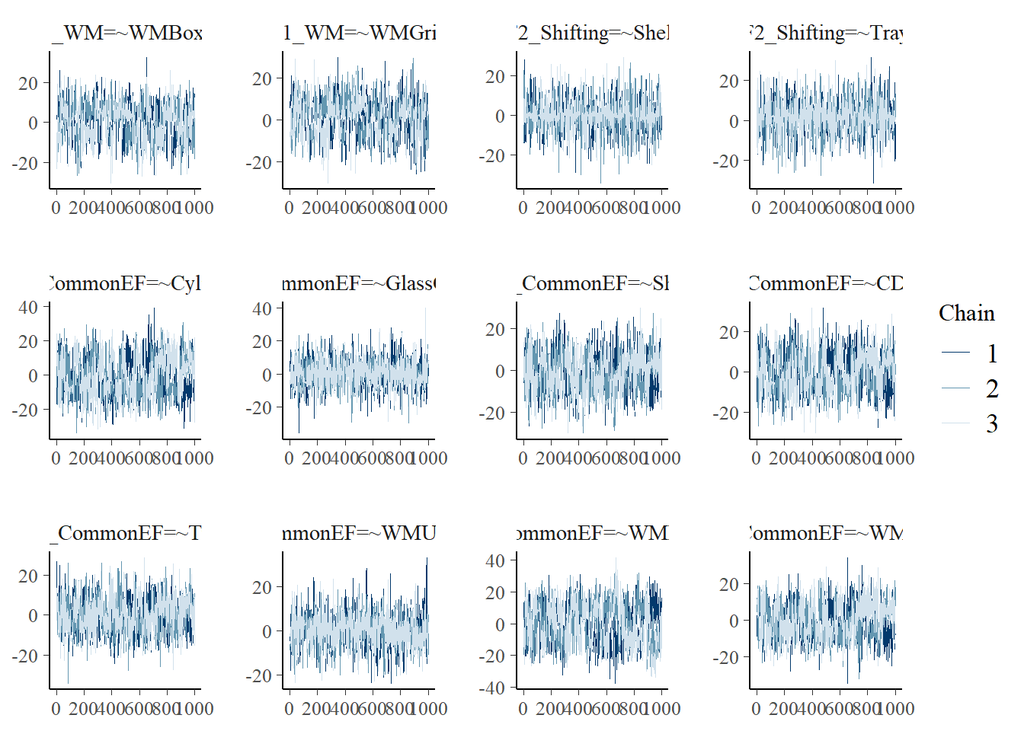

```r
plot(bfit.MF2012, pars = 1:12)
```

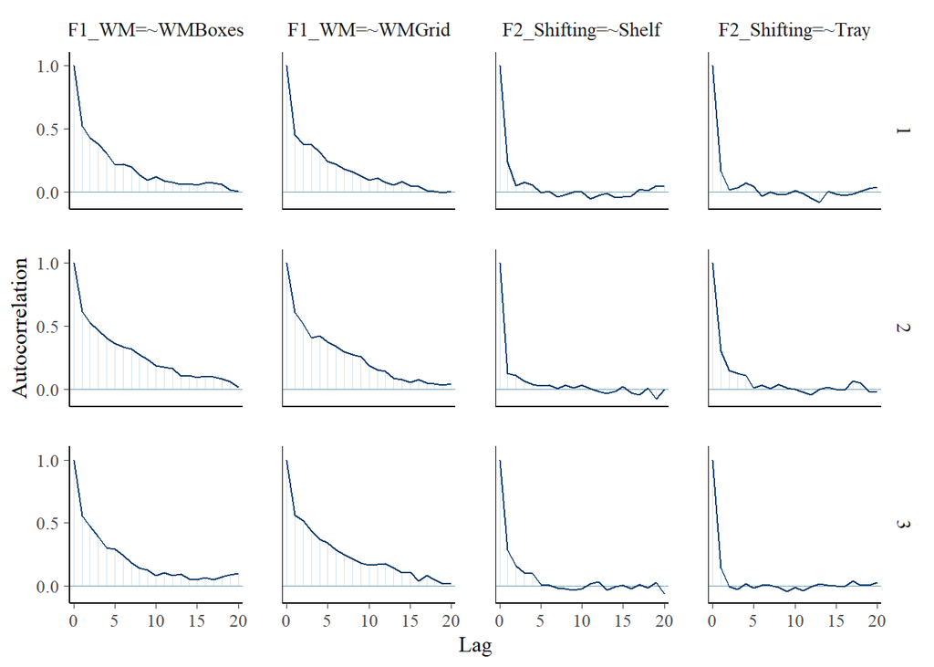

```r
plot(bfit.MF2012, pars = 1:4, plot.type = "acf")
```

```r
fm.MF2012<-fitMeasures(bfit.MF2012)
fm.3factors<-fitMeasures(bfit.3factors)
fm.1factor<-fitMeasures(bfit.1factor)
fm.3factors_ind<-fitMeasures(bfit.3factors_ind)
fm.2factors1<-fitMeasures(bfit.2factors1)
fm.2factors2<-fitMeasures(bfit.2factors2)
fm.2factors3<-fitMeasures(bfit.2factors3)
fm.9factors<-fitMeasures(bfit.9factors)
rbind(fm.MF2012, fm.3factors, fm.3factors_ind,  fm.1factor, fm.2factors1, fm.2factors2, fm.2factors3, fm.9factors)
```

```
##                 npar      logl        ppp      bic      dic     p_dic     waic
## fm.MF2012         33 -667.6959 0.16233333 1465.783 1330.092 -2.649794 1357.891
## fm.3factors       27 -660.3773 0.10600000 1427.438 1351.785 15.515222 1359.327
## fm.3factors_ind   27 -657.1485 0.09666667 1420.980 1358.627 22.164805 1358.752
## fm.1factor        27 -661.1756 0.11666667 1429.035 1349.071 13.359859 1358.996
## fm.2factors1      27 -660.9824 0.13066667 1428.648 1346.835 12.434818 1357.545
## fm.2factors2      27 -660.4894 0.09533333 1427.662 1352.817 15.919006 1359.852
## fm.2factors3      27 -661.0329 0.08333333 1428.749 1353.229 15.581693 1359.897
## fm.9factors       18 -662.8912 0.03733333 1396.905 1360.101 17.159369 1359.933
##                   p_waic  se_waic    looic    p_loo   se_loo margloglik
## fm.MF2012       24.01554 34.62048 1358.252 24.19587 34.67500  -745.7331
## fm.3factors     21.73660 34.27242 1359.595 21.87023 34.30835  -731.4550
## fm.3factors_ind 21.04330 34.27442 1358.925 21.12994 34.29629  -728.7551
## fm.1factor      22.48110 34.53841 1359.433 22.69952 34.61597  -734.5492
## fm.2factors1    21.95099 34.22117 1357.981 22.16886 34.32317  -733.6971
## fm.2factors2    21.83623 34.52148 1360.210 22.01563 34.59453  -733.4488
## fm.2factors3    21.19457 34.63094 1360.294 21.39327 34.69876  -734.2852
## fm.9factors     16.17883 34.28714 1360.100 16.26205 34.30953  -728.3321
```

```r
summary(bfit.MF2012, neff=TRUE)
```

```
## blavaan (0.3-10) results of 1000 samples after 2000 adapt/burnin iterations
##
##   Number of observations                            53
##
##   Number of missing patterns                         5
##
##   Statistic                                 MargLogLik         PPP
##   Value                                       -745.733       0.162
##
## Latent Variables:
##                    Estimate  Post.SD pi.lower pi.upper     Rhat     neff
##   F1_WM =~
##     WMUpdating        1.000                                  NA       NA
##     WMBoxes           0.498    8.202  -16.492   15.714    1.013  317.156
##     WMGrid            0.871    8.282  -16.168   17.049    1.015  301.045
##   F2_Shifting =~
##     CD_all            1.000                                  NA       NA
##     Shelf             0.206    7.093  -15.501    15.93    1.000 1517.488
##     Tray              1.715    7.469  -15.197   17.343    1.002 1688.194
##   F3_CommonEF =~
##     InhibGrid         1.000                                  NA       NA
##     Cylinder          0.249    6.861  -13.758   14.082    1.001 1130.955
##     GlassCeiling      0.469   12.454  -22.411    21.96    1.013  141.347
##     Shelf            -0.415    9.493   -17.41   17.891    1.013  224.157
##     CD_all           -0.444    9.439  -18.062   17.847    1.008  208.167
##     Tray             -0.770    8.969  -17.804   16.748    1.006  278.520
##     WMUpdating       -0.095    8.334  -15.963   16.296    1.005  326.475
##     WMBoxes          -0.416   11.088  -20.787   20.477    1.010  183.873
##     WMGrid            0.502    7.643   -14.96   15.948    1.000 1620.076
##     Prior
##
##
##     normal(0,10)
##     normal(0,10)
##
##
##     normal(0,10)
##     normal(0,10)
##
##
```

[output cut: 63 more lines]

```
##     F2_Shifting       0.025    0.070        0    0.203    1.004  640.799
##     F3_CommonEF       0.001    0.001        0    0.005    1.003  785.105
##     Prior
##  gamma(1,.5)[sd]
##  gamma(1,.5)[sd]
##  gamma(1,.5)[sd]
##  gamma(1,.5)[sd]
##  gamma(1,.5)[sd]
##  gamma(1,.5)[sd]
##  gamma(1,.5)[sd]
##  gamma(1,.5)[sd]
##  gamma(1,.5)[sd]
##  gamma(1,.5)[sd]
##  gamma(1,.5)[sd]
##  gamma(1,.5)[sd]
```